# Analytics Edge: Unit 6 - Segmenting Images to Create Data

Sulman Khan

October 26, 2018

## Seeing the Big Picture

### Image Segmentation

- Divide up digital images to salient regions/clusters corresponding to individual surfaces, objects, or natural parts of objects
- Clusters should be uniform and homogeneous with respect to certain characteristics (color, intensity, texture)
- **Goal:** Useful and analyzable image representation

### Wide Applications

- **Medical Imaging**
  - **Locate tissues classes**, organs, pathologist, and **tumors**
  - Measure tissue/tumor volume
- Object Detection
  - Detect facial features in photos
  - Detect pedestrians in footage of surveillance videos
- Recognition tasks
  - Fingerprint/Iris recognition

### Various Methods

- **Clustering methods**
  - Partition image to clusters based on differences in pixel colors, intensity, or texture
- Edge detection
  - Based on detection of discontinuity, such as an abrupt change in the gray level in gray-scale images
- Region-growing methods
  - Divides image into regions, then sequentially merges sufficiently similar regions

### Implementation

- Restrict ourselves to gray-scale images
  - Simple example of a flower image (flower.csv)
  - Medical imaging application with examples of transverse MRI images of the brain (healthy.csv and tumor.csv)
- Compare the use, pros and cons of all analytics techniques learned thus far

### Grayscale Images

- Image is represented as a matrix of pixel intensity values ranging from 0 (black) to 1 (white)
- For 8 bits / pixel (bpp), 256 color levels

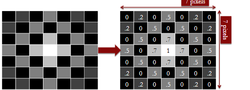

### Grayscale Image Segmentation

- Cluster pixels according to their intensity values

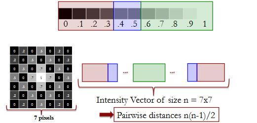

### Flower Dendogram

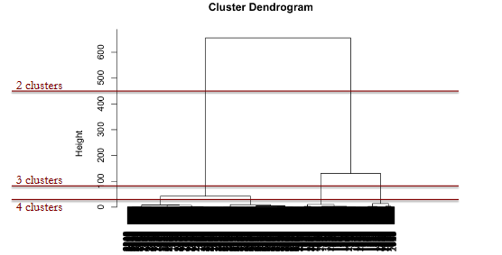

### *k* - Means Clustering

- The *k*-means clustering aims at partitioning the data in *k* clusters in which each data point belongs to the cluster whose mean is the nearest

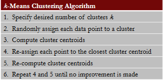

### Segmented MRI Images

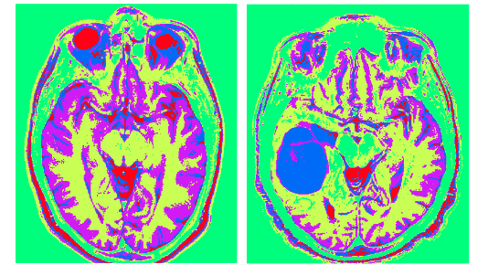

### T2 Weighted MRI Images

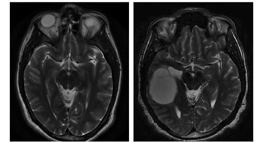

### Comparison of Methods

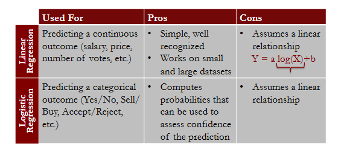

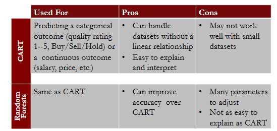

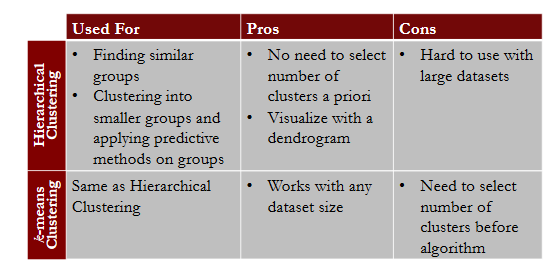

## Image Segmentation in R

### Load in the Data

```r
# Load dataset in R
flower = read.csv("flower.csv", header=FALSE)
# Output string
str(flower)
```

```
## 'data.frame':    50 obs. of  50 variables:
##  $ V1 : num  0.0991 0.0991 0.1034 0.1034 0.1034 ...
##  $ V2 : num  0.112 0.108 0.112 0.116 0.108 ...
##  $ V3 : num  0.134 0.116 0.121 0.116 0.112 ...
##  $ V4 : num  0.138 0.138 0.121 0.121 0.112 ...
##  $ V5 : num  0.138 0.134 0.125 0.116 0.112 ...
##  $ V6 : num  0.138 0.129 0.121 0.108 0.112 ...
##  $ V7 : num  0.129 0.116 0.103 0.108 0.112 ...
##  $ V8 : num  0.116 0.103 0.103 0.103 0.116 ...
##  $ V9 : num  0.1121 0.0991 0.1078 0.1121 0.1164 ...
##  $ V10: num  0.121 0.108 0.112 0.116 0.125 ...
##  $ V11: num  0.134 0.125 0.129 0.134 0.129 ...
##  $ V12: num  0.147 0.134 0.138 0.129 0.138 ...
##  $ V13: num  0.000862 0.146552 0.142241 0.142241 0.133621 ...
##  $ V14: num  0.000862 0.000862 0.142241 0.133621 0.12931 ...
```

[output cut: 36 more lines]

### Change the data type to matrix

```r
# Change data type to matrix
flowerMatrix = as.matrix(flower)
# Output string
str(flowerMatrix)
```

```
##  num [1:50, 1:50] 0.0991 0.0991 0.1034 0.1034 0.1034 ...
##  - attr(*, "dimnames")=List of 2
##   ..$ : NULL
##   ..$ : chr [1:50] "V1" "V2" "V3" "V4" ...
```

### Turn matrix into a vector

```r
# Turn matrix into vector
flowerVector = as.vector(flowerMatrix)
# Output string
str(flowerVector)
```

```
##  num [1:2500] 0.0991 0.0991 0.1034 0.1034 0.1034 ...
```

```r
# Turn matrix into vecotr
flowerVector2 = as.vector(flower)
# Output string
str(flowerVector2)
```

```
## 'data.frame':    50 obs. of  50 variables:
##  $ V1 : num  0.0991 0.0991 0.1034 0.1034 0.1034 ...
##  $ V2 : num  0.112 0.108 0.112 0.116 0.108 ...
##  $ V3 : num  0.134 0.116 0.121 0.116 0.112 ...
##  $ V4 : num  0.138 0.138 0.121 0.121 0.112 ...
##  $ V5 : num  0.138 0.134 0.125 0.116 0.112 ...
##  $ V6 : num  0.138 0.129 0.121 0.108 0.112 ...
##  $ V7 : num  0.129 0.116 0.103 0.108 0.112 ...
##  $ V8 : num  0.116 0.103 0.103 0.103 0.116 ...
##  $ V9 : num  0.1121 0.0991 0.1078 0.1121 0.1164 ...
##  $ V10: num  0.121 0.108 0.112 0.116 0.125 ...
##  $ V11: num  0.134 0.125 0.129 0.134 0.129 ...
##  $ V12: num  0.147 0.134 0.138 0.129 0.138 ...
##  $ V13: num  0.000862 0.146552 0.142241 0.142241 0.133621 ...
##  $ V14: num  0.000862 0.000862 0.142241 0.133621 0.12931 ...
```

[output cut: 36 more lines]

### Compute distances

```r
# Compute euclidean distance
distance = dist(flowerVector, method = "euclidean")
```

### Hierarchical clustering

```r
# Implement hierarchical clustering
clusterIntensity = hclust(distance, method="ward")
```

### Plot the dendrogram

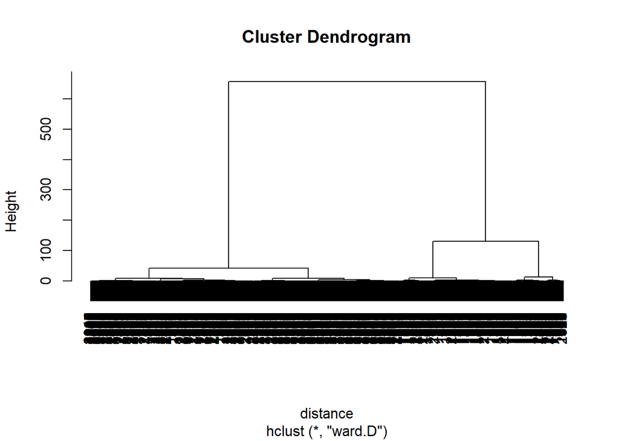

```r
# Plot the dendrogram
plot(clusterIntensity)
```

### Select 3 clusters

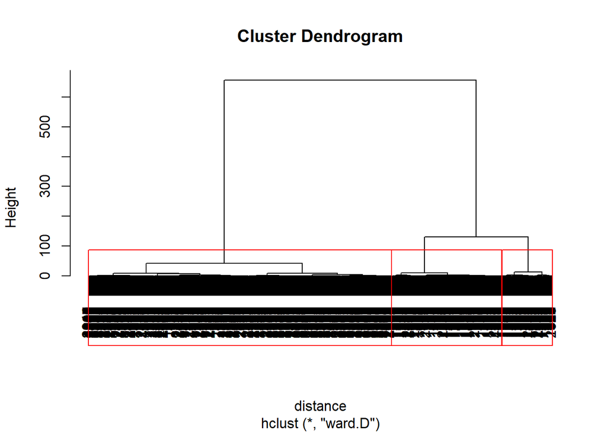

```r
# Plot dendrodrogram
plot(clusterIntensity)
# Create 3 clusters on the dendrogram
rect.hclust(clusterIntensity, k = 3, border = "red")
```

```r
# Divide the dataset into 3 clusters
flowerClusters = cutree(clusterIntensity, k = 3)
library(xtable)
flowerClusters
```

[output not shown]

### Find mean intensity values

```r
# Compare two groups using a statistical measure
z = tapply(flowerVector, flowerClusters, mean)
kable(z)
```

| x |
| --- |
| 0.08574315 |
| 0.50826255 |
| 0.93147713 |

### Plot the image and the clusters

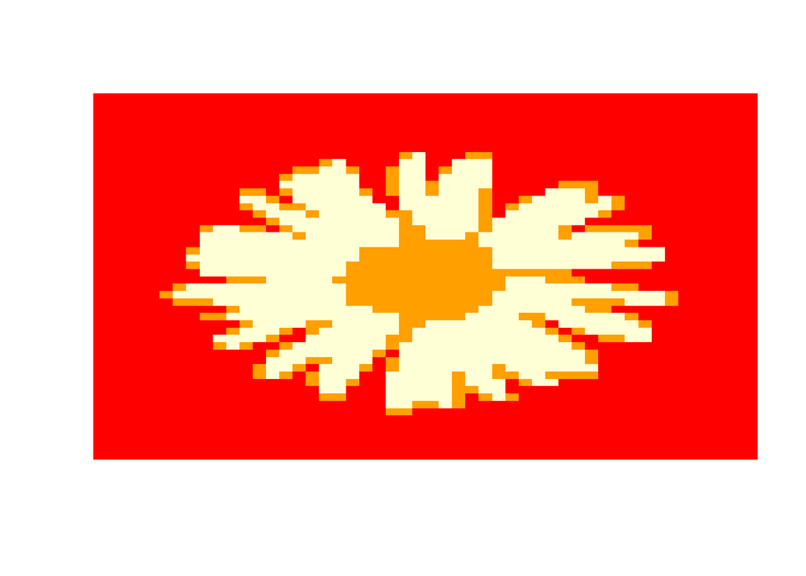

```r
# Set the dimensions of the image
dim(flowerClusters) = c(50,50)
image(flowerClusters, axes = FALSE)
```

### Original image

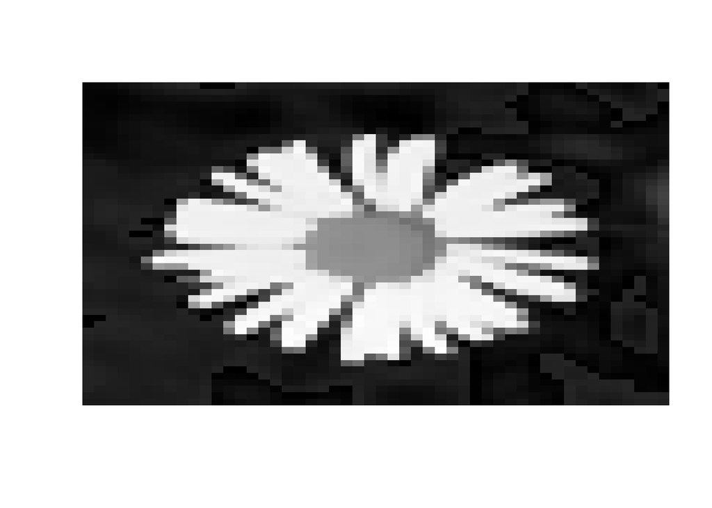

```r
# Original Image
image(flowerMatrix,axes=FALSE,col=grey(seq(0,1,length=256)))
```

### Let’s try this with an MRI image of the brain

```r
# Load the dataset
healthy = read.csv("healthy.csv", header=FALSE)
# Convert into a matrix
healthyMatrix = as.matrix(healthy)
str(healthyMatrix)
```

```
##  num [1:566, 1:646] 0.00427 0.00855 0.01282 0.01282 0.01282 ...
##  - attr(*, "dimnames")=List of 2
##   ..$ : NULL
##   ..$ : chr [1:646] "V1" "V2" "V3" "V4" ...
```

#### Plot image

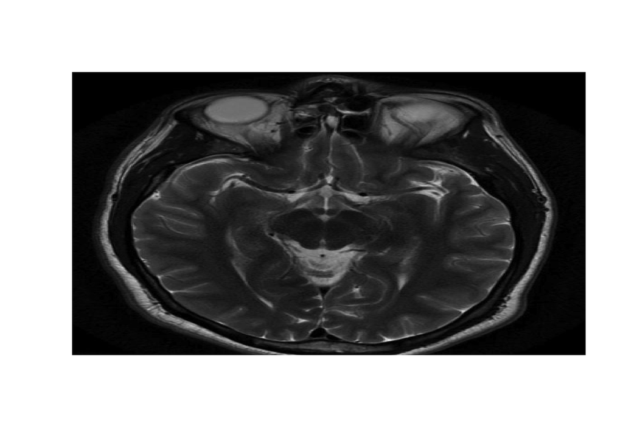

```r
# Plot the image
image(healthyMatrix,axes=FALSE,col=grey(seq(0,1,length=256)))
```

#### Hierarchial clustering

```r
# Change into a vector
healthyVector = as.vector(healthyMatrix)
```

distance = dist(healthyVector, method = “euclidean”)

Cannot compute the distance because the vector is very large.

#### Specify number of clusters

```r
# Number of clusters
k = 5
```

#### Run k-means

```r
# Implement the k - means algorithm
set.seed(1)
KMC = kmeans(healthyVector, centers = k, iter.max = 1000)
str(KMC)
```

```
## List of 9
##  $ cluster     : int [1:365636] 3 3 3 3 3 3 3 3 3 3 ...
##  $ centers     : num [1:5, 1] 0.4818 0.1062 0.0196 0.3094 0.1842
##   ..- attr(*, "dimnames")=List of 2
##   .. ..$ : chr [1:5] "1" "2" "3" "4" ...
##   .. ..$ : NULL
##  $ totss       : num 5775
##  $ withinss    : num [1:5] 96.6 47.2 39.2 57.5 62.3
##  $ tot.withinss: num 303
##  $ betweenss   : num 5472
##  $ size        : int [1:5] 20556 101085 133162 31555 79278
##  $ iter        : int 2
##  $ ifault      : int 0
##  - attr(*, "class")= chr "kmeans"
```

#### Extract clusters

```r
# Extract clusters
healthyClusters = KMC$cluster
KMC$centers[2]
```

```
## [1] 0.1061945
```

#### Plot the image with the clusters

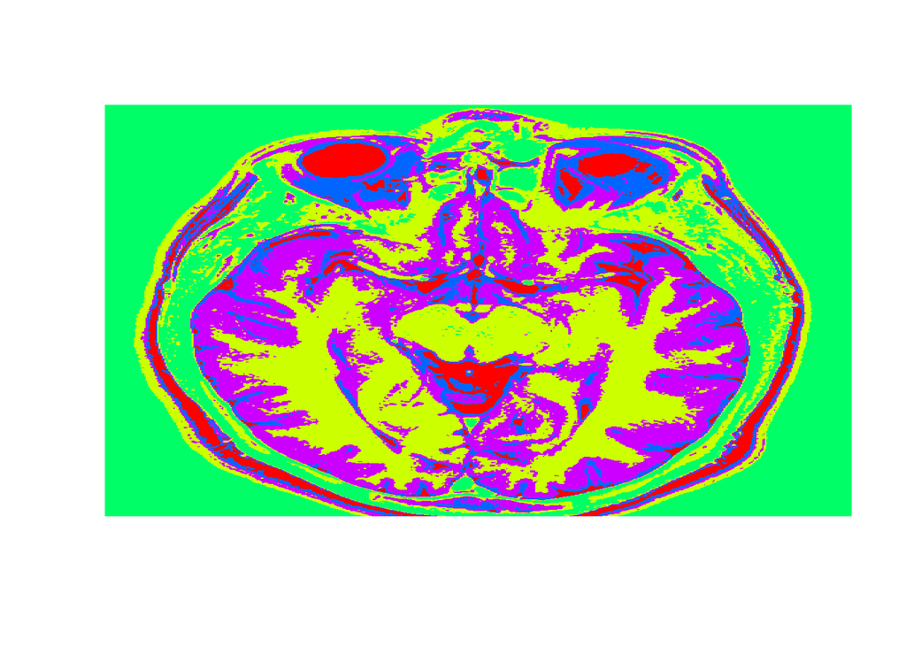

```r
# Plot the image with clusters
dim(healthyClusters) = c(nrow(healthyMatrix), ncol(healthyMatrix))

image(healthyClusters, axes = FALSE, col=rainbow(k))
```

### Apply to a test image

```r
# Load dataset
tumor = read.csv("tumor.csv", header=FALSE)
# Convert to matrix
tumorMatrix = as.matrix(tumor)
# Convert to vector
tumorVector = as.vector(tumorMatrix)
```

#### Apply clusters from before to new image, using the flexclust package

```r
# Implement the flexclust package and apply clusters from before to new image
library(flexclust)
KMC.kcca = as.kcca(KMC, healthyVector)
tumorClusters = predict(KMC.kcca, newdata = tumorVector)
```

#### Visualize the clusters

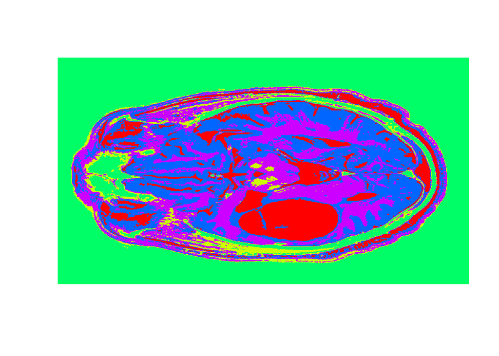

```r
# Visualize the clusters
dim(tumorClusters) = c(nrow(tumorMatrix), ncol(tumorMatrix))
image(tumorClusters, axes = FALSE, col=rainbow(k))
```